# Grando-Final

John Grando

May 18, 2017

## Grando - Final

### Part I

#### Question 1 - A student is gathering data on the driving experiences of other college students. A description of the data car color is presented below. Which of the variables are quantitative and discrete?

Answer:

4. daysDrive, gasMonth

daysDrive- Since this is indicated to be a count of days then it appears this value can only take on whole non-negative integers for the number of days the student drives.

gasMonth - This value is indicated to be cost, which is only calculated down to the nearest $0.01. Therefore, there are not an infinite number of possible values for a given variable range. Also, note that if this value were calculated in cents, then it would be all non-negative integers which is similar to the daysDrive variable.

Answer:

Since the data appears to have a left skew, we can immediately remove any option that states the mean is greater than the median (b, d).

1. mean = 3.3, median = 3.5

#### Question 3 - A researcher wants to determine if a new treatment is effective for reducing Ebola related fever. What type of study should be conducted in order to establish that the treatment does indeed cause improvement in Ebola patients?

Answer:

1. Randomly assign Ebola patients to one of two groups, either the treatment or placebo group, and then compare the fever of the two groups

Option d (Both a and b) is not acceptable because it is not guaranteed that the sample is randomized and could contain an unknown bias. Additionally, by not having a placebo group, we cannot be certain that we have appropriately set up the experiment to compare for a difference of only one variable (i.e. the treament)

#### Question 4 - A study is designed to test whether there is a relationship between natural hair color (brunette, blond, red) and eye color (blue, green, brown). If a large χ2 test statistic is obtained, this suggests that:

Answer:

3. there is an association between natural hair color and eye color.

#### Question 5 - A researcher studying how monkeys remember is interested in examining the distribution of the score on a standard memory task. The researcher wants to produce a boxplot to examine this distribution. Below are summary statistics from the memory task. What values should the researcher use to determine if a particular score is a potential outlier in the boxplot?

Answer:

To determine possible outliers, the researcher would examine points that fell beyond the whisker limits of the boxplot, which are 1.5 * IQR.

```r
Q1 <- 37
Q3 <- 49.8
IQR <- Q3 - Q1
(Lower_whisker <- 37 - 1.5 * IQR)
```

```
## [1] 17.8
```

```r
(Upper_whisker <- 49.8 + 1.5 * IQR)
```

```
## [1] 69
```

2. 17.8 and 69.0

#### Question 6 - The [blank] are resistant to outliers, whereas the [blank] are not.

Answer:

4. median and interquartile range; mean and standard deviation

#### a. Describe the two distributions (2 pts).

Answer:

#### b. Explain why the means of these two distributions are similar but the standard deviations are not (2 pts).

Answer:

Figure B is a representation of the sample means taken from figure A. Therefore this figure is a summary of point estimates and if a sample consists of enough independent observations (usually at least 30) and the data are not strongly skewed, then the distribution of the sample mean would be approximated by a normal model centered around the mean.

The standard deviations differ between Figure A and B because Figure B is a distribution of point estimates based on samples of 30. Therefore, the standard deviation of Figure B is the typical error or uncertainty associated with the point estimate based on the number of samples taken. Figure A is the distribution of the actual variable; therefore the standard deviation associated with this distribution roughly describes how far away the typical observation is from the mean.

#### c. What is the statistical principal that describes this phenomenon (2 pts)?

Answer:

The statistical principal that describes this phenomenom is the Central Limit Theorem (CLT). It is described as follows:

$$\underset { n\rightarrow \infty }{ lim } P\left( \frac { \bar { X } -\mu }{ \sigma /\sqrt { n } } \le z \right) =\Phi \left( z \right)$$

where $\Phi$ is the cumulative distribution function (cdf) of the standard normal distribution.

In other words, the distribution of a sample mean taken from a population is well approximated by a normal model:

$$\bar { x } \sim N\left( mean=\mu ,SE=\frac { \sigma }{ \sqrt { n } } \right)$$

### Part II

Consider the four datasets, each with two columns (x and y), provided below.

```r
options(digits = 2)
data1 <- data.frame(x = c(10, 8, 13, 9, 11, 14, 6, 4, 12, 7, 5), y = c(8.04, 6.95, 7.58, 8.81,
    8.33, 9.96, 7.24, 4.26, 10.84, 4.82, 5.68))
data2 <- data.frame(x = c(10, 8, 13, 9, 11, 14, 6, 4, 12, 7, 5), y = c(9.14, 8.14, 8.74, 8.77,
    9.26, 8.1, 6.13, 3.1, 9.13, 7.26, 4.74))
data3 <- data.frame(x = c(10, 8, 13, 9, 11, 14, 6, 4, 12, 7, 5), y = c(7.46, 6.77, 12.74, 7.11,
    7.81, 8.84, 6.08, 5.39, 8.15, 6.42, 5.73))
data4 <- data.frame(x = c(8, 8, 8, 8, 8, 8, 8, 19, 8, 8, 8), y = c(6.58, 5.76, 7.71, 8.84,
    8.47, 7.04, 5.25, 12.5, 5.56, 7.91, 6.89))
```

For each column, calculate (to two decimal places):

#### a. The mean (for x and y separately; 1 pt).

Answer:

```r
options(digits = 2)
format(mean(data1$x), nsmall = 2)
```

```
## [1] "9.00"
```

```r
format(mean(data1$y), nsmall = 2)
```

```
## [1] "7.50"
```

```r
format(mean(data2$x), nsmall = 2)
```

```
## [1] "9.00"
```

```r
format(mean(data2$y), nsmall = 2)
```

```
## [1] "7.50"
```

```r
format(mean(data3$x), nsmall = 2)
```

```
## [1] "9.00"
```

```r
format(mean(data3$y), nsmall = 2)
```

```
## [1] "7.50"
```

```r
format(mean(data4$x), nsmall = 2)
```

```
## [1] "9.00"
```

```r
format(mean(data4$y), nsmall = 2)
```

```
## [1] "7.50"
```

#### b. The median (for x and y separately; 1 pt).

Answer:

```r
options(digits = 2)
format(median(data1$x), nsmall = 2)
```

```
## [1] "9.00"
```

```r
format(median(data1$y), nsmall = 2)
```

```
## [1] "7.58"
```

```r
format(median(data2$x), nsmall = 2)
```

```
## [1] "9.00"
```

```r
format(median(data2$y), nsmall = 2)
```

```
## [1] "8.14"
```

```r
format(median(data3$x), nsmall = 2)
```

```
## [1] "9.00"
```

```r
format(median(data3$y), nsmall = 2)
```

```
## [1] "7.11"
```

```r
format(median(data4$x), nsmall = 2)
```

```
## [1] "8.00"
```

```r
format(median(data4$y), nsmall = 2)
```

```
## [1] "7.04"
```

#### c. The standard deviation (for x and y separately; 1 pt).

Answer:

```r
options(digits = 2)
format(sd(data1$x), nsmall = 2)
```

```
## [1] "3.32"
```

```r
format(sd(data1$y), nsmall = 2)
```

```
## [1] "2.03"
```

```r
format(sd(data2$x), nsmall = 2)
```

```
## [1] "3.32"
```

```r
format(sd(data2$y), nsmall = 2)
```

```
## [1] "2.03"
```

```r
format(sd(data3$x), nsmall = 2)
```

```
## [1] "3.32"
```

```r
format(sd(data3$y), nsmall = 2)
```

```
## [1] "2.03"
```

```r
format(sd(data4$x), nsmall = 2)
```

```
## [1] "3.32"
```

```r
format(sd(data4$y), nsmall = 2)
```

```
## [1] "2.03"
```

For each x and y pair, calculate (also to two decimal places; 1 pt):

#### d. The correlation (1 pt).

Answer:

```r
options(digits = 2)
format(cor(data1$x, data1$y), nsmall = 2)
```

```
## [1] "0.82"
```

```r
format(cor(data2$x, data2$y), nsmall = 2)
```

```
## [1] "0.82"
```

```r
format(cor(data3$x, data3$y), nsmall = 2)
```

```
## [1] "0.82"
```

```r
format(cor(data4$x, data4$y), nsmall = 2)
```

```
## [1] "0.82"
```

#### e. Linear regression equation (2 pts).

Answer:

```r
lm_d1 <- lm(y ~ x, data = data1)
summary(lm_d1)
```

```
##
## Call:
## lm(formula = y ~ x, data = data1)
##
## Residuals:
##     Min      1Q  Median      3Q     Max
## -1.9213 -0.4558 -0.0414  0.7094  1.8388
##
## Coefficients:
##             Estimate Std. Error t value Pr(>|t|)
## (Intercept)    3.000      1.125    2.67   0.0257 *
## x              0.500      0.118    4.24   0.0022 **
## ---
## Signif. codes:  0 '***' 0.001 '**' 0.01 '*' 0.05 '.' 0.1 ' ' 1
##
## Residual standard error: 1.2 on 9 degrees of freedom
## Multiple R-squared:  0.667,  Adjusted R-squared:  0.629
## F-statistic:   18 on 1 and 9 DF,  p-value: 0.00217
```

```r
lm_d2 <- lm(y ~ x, data = data2)
summary(lm_d2)
```

```
##
## Call:
## lm(formula = y ~ x, data = data2)
##
## Residuals:
##    Min     1Q Median     3Q    Max
## -1.901 -0.761  0.129  0.949  1.269
##
## Coefficients:
##             Estimate Std. Error t value Pr(>|t|)
## (Intercept)    3.001      1.125    2.67   0.0258 *
## x              0.500      0.118    4.24   0.0022 **
## ---
## Signif. codes:  0 '***' 0.001 '**' 0.01 '*' 0.05 '.' 0.1 ' ' 1
##
## Residual standard error: 1.2 on 9 degrees of freedom
## Multiple R-squared:  0.666,  Adjusted R-squared:  0.629
## F-statistic:   18 on 1 and 9 DF,  p-value: 0.00218
```

```r
lm_d3 <- lm(y ~ x, data = data3)
summary(lm_d3)
```

```
##
## Call:
## lm(formula = y ~ x, data = data3)
##
## Residuals:
##    Min     1Q Median     3Q    Max
## -1.159 -0.615 -0.230  0.154  3.241
##
## Coefficients:
##             Estimate Std. Error t value Pr(>|t|)
## (Intercept)    3.002      1.124    2.67   0.0256 *
## x              0.500      0.118    4.24   0.0022 **
## ---
## Signif. codes:  0 '***' 0.001 '**' 0.01 '*' 0.05 '.' 0.1 ' ' 1
##
## Residual standard error: 1.2 on 9 degrees of freedom
## Multiple R-squared:  0.666,  Adjusted R-squared:  0.629
## F-statistic:   18 on 1 and 9 DF,  p-value: 0.00218
```

```r
lm_d4 <- lm(y ~ x, data = data4)
summary(lm_d4)
```

```
##
## Call:
## lm(formula = y ~ x, data = data4)
##
## Residuals:
##    Min     1Q Median     3Q    Max
## -1.751 -0.831  0.000  0.809  1.839
##
## Coefficients:
##             Estimate Std. Error t value Pr(>|t|)
## (Intercept)    3.002      1.124    2.67   0.0256 *
## x              0.500      0.118    4.24   0.0022 **
## ---
## Signif. codes:  0 '***' 0.001 '**' 0.01 '*' 0.05 '.' 0.1 ' ' 1
##
## Residual standard error: 1.2 on 9 degrees of freedom
## Multiple R-squared:  0.667,  Adjusted R-squared:  0.63
## F-statistic:   18 on 1 and 9 DF,  p-value: 0.00216
```

the linear equation for all data sets is as follows:

$$\widehat { y } \quad ={ \quad \beta }_{ 0 }\quad +\quad { \beta }_{ 1 }\quad *\quad x\\ \widehat { y } \quad =\quad 3.00\quad +\quad 0.50\quad *\quad x$$

#### f. R-Squared (2 pts).

Answer:

```r
options(digits = 2)

# two methods are used to show the r-squared value for each data set.
format(cor(data1$y, data1$x)^2, nsmall = 2)
```

```
## [1] "0.67"
```

```r
format(summary(lm(y ~ x, data = data1))[[8]], nsmall = 2)
```

```
## [1] "0.67"
```

```r
format(cor(data2$y, data2$x)^2, nsmall = 2)
```

```
## [1] "0.67"
```

```r
format(summary(lm(y ~ x, data = data2))[[8]], nsmall = 2)
```

```
## [1] "0.67"
```

```r
format(cor(data3$y, data3$x)^2, nsmall = 2)
```

```
## [1] "0.67"
```

```r
format(summary(lm(y ~ x, data = data3))[[8]], nsmall = 2)
```

```
## [1] "0.67"
```

```r
format(cor(data4$y, data4$x)^2, nsmall = 2)
```

```
## [1] "0.67"
```

```r
format(summary(lm(y ~ x, data = data4))[[8]], nsmall = 2)
```

```
## [1] "0.67"
```

#### For each pair, is it appropriate to estimate a linear regression model? Why or why not? Be specific as to why for each pair and include appropriate plots! (4 pts)

Answer:

1. First we should visually inspect the data to ensure it has a linear pattern.

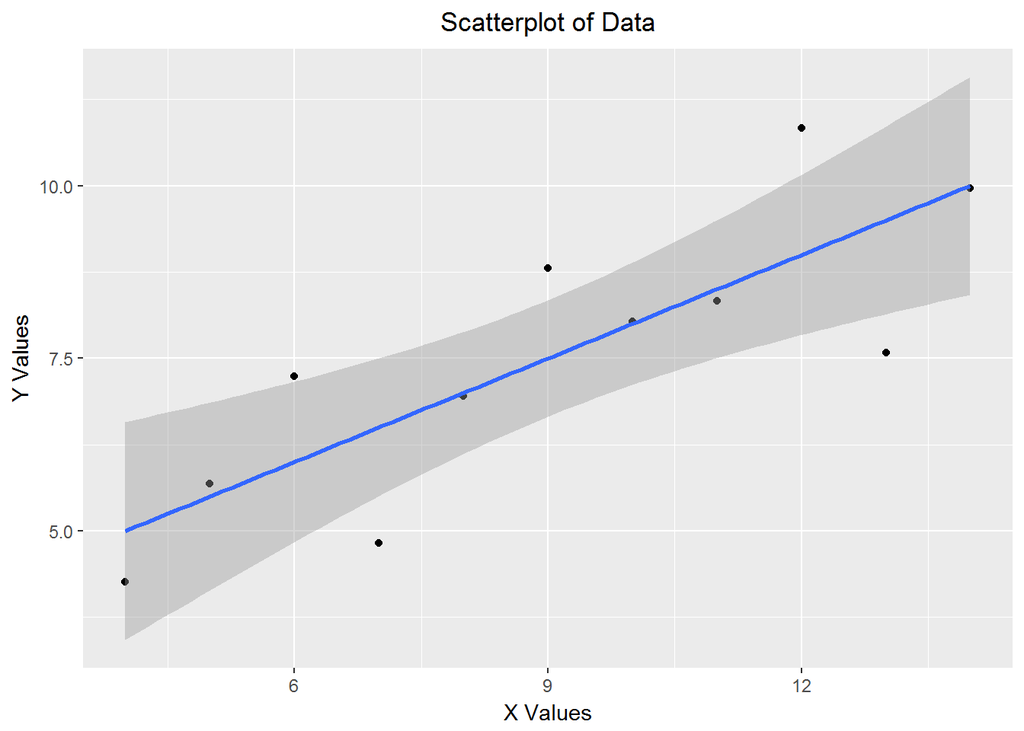

```r
require(ggplot2)
ggplot(data1, aes(y = y, x = x)) + geom_point() + geom_smooth(method = lm, fullrange = TRUE) +
    labs(x = "X Values", y = "Y Values") + ggtitle("Scatterplot of Data") + theme(plot.title = element_text(hjust = 0.5))
```

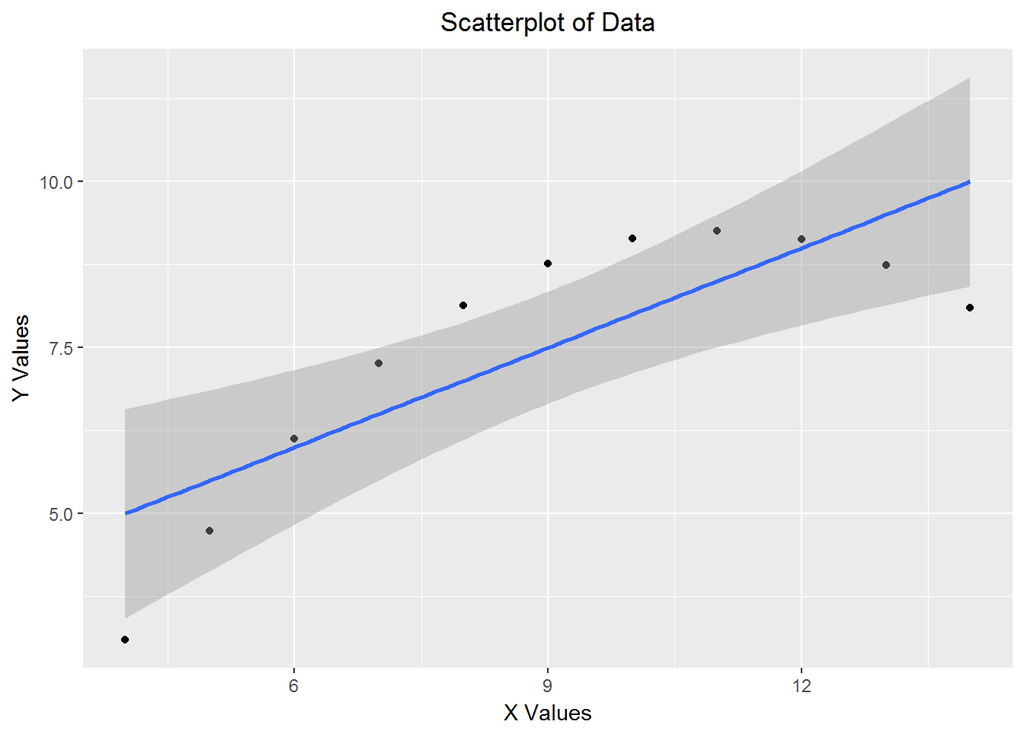

```r
ggplot(data2, aes(y = y, x = x)) + geom_point() + geom_smooth(method = lm, fullrange = TRUE) +
    labs(x = "X Values", y = "Y Values") + ggtitle("Scatterplot of Data") + theme(plot.title = element_text(hjust = 0.5))
```

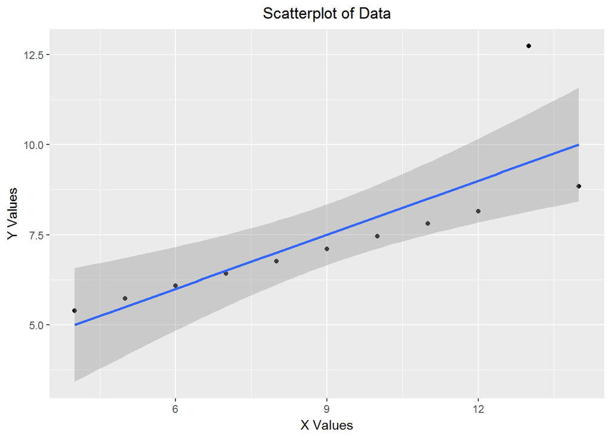

```r
ggplot(data3, aes(y = y, x = x)) + geom_point() + geom_smooth(method = lm, fullrange = TRUE) +
    labs(x = "X Values", y = "Y Values") + ggtitle("Scatterplot of Data") + theme(plot.title = element_text(hjust = 0.5))
```